# Estatística Computacional I

Trabalho 02 - (21/05/2020)

Orientações:

1. Responda as questões deixando o código R nos respectivos chunks
2. Mantenha os nomes de objetos solicitados na questão
3. Sempre deixe por último o objeto que responde a pergunta
4. Salve o arquivo com o seu nome
5. Execute o Preview para gerar o html
6. Envie o html e Rmd pelo CR 7 . link do arquivo: [https://bit.ly/2WRHoXB]

## 1- Leia o arquivo forbes2000.csv carregando-o em um objeto com nome df.

```r
df = read.csv("F:/files/R/Trabalho01/forbes2000.csv", sep = ';', dec = ',')
```

A lista Forbes 2000 é um ranking das maiores empresas do mundo, medido por vendas, lucros, ativos e valor de mercado.

## 2- Renomeie as colunas com os nomes a seguir, que já estão na ordem das colunas como segue: rank, empresa, pais, categoria, vendas, lucro, ativo, valor).Mantenha o nome df.

```r
colnames(df) = c('rank','empresa','pais','categoria','vendas','lucro','ativo','valor')
```

## 3- Quantos e quais países estão nesta lista?

```r
n_paises = length(unique(df$pais))
paises = unique(df$pais)
```

## 4- Qual são os 10 paises que aparecem com mais frequencia? Faça uma tabela com o nome do país e a frequencia.

```r
freq_paises = sort(table(df$pais),decreasing = TRUE)
freq_paises = freq_paises[1:10]
kable(freq_paises, row.names = FALSE, col.names = c('Países','Frequência'))
```

| Países | Frequência |
| --- | --- |
| United States | 751 |
| Japan | 316 |
| United Kingdom | 137 |
| Germany | 65 |
| France | 63 |
| Canada | 56 |
| South Korea | 45 |
| Italy | 41 |
| Australia | 37 |
| Taiwan | 35 |

## 5- Quantas e quais são as empresas brasileiras? A lista de empresas deve estar em ordem alfabética

```r
empresas_br = sort(df$empresa[which(df$pais == 'Brazil')])
kable(empresas_br,row.names = FALSE, col.names = "Empresas Brasileiras")
```

| Empresas Brasileiras |
| --- |
| AmBev |
| Aracruz Celulose |
| Banco Bradesco Group |
| Banco do Brasil |
| Brasil Telecom |
| CBD-Brasil Distribuieco |
| CSN-Cia Siderurgica |
| Eletrobras |
| Embraer |
| Itazsa |
| Metalurgica Gerdau |
| Petrobras-Petrsleo Brasil |
| Tele Norte Leste |
| Unibanco Group |
| Vale do Rio Doce |

## 6- Compare os valor médio das empresas brasileiras com as demais empresas. Calcule a média e variância. O resultado deve ser uma tabela com as colunas País,Média_Vendas e Variância_Vendas.

```r
brasil_dados = c("Brasil",mean(df$valor[which(df$pais == 'Brazil')]),var(df$valor[which(df$pais == 'Brazil')]))
mundo_dados = c("Restante do Mundo",mean(df$valor[which(df$pais != 'Brazil')]),var(df$valor[which(df$pais != 'Brazil')]))
kable(matrix(c(brasil_dados,mundo_dados),nrow = 2,ncol = 3,byrow = TRUE), row.names = FALSE, col.names = c("País", "Média_Valor", "Variância_Valor"))
```

| País | Média_Valor | Variância_Valor |
| --- | --- | --- |
| Brasil | 7.718 | 81.5038742857143 |
| Restante do Mundo | 11.9090881612091 | 602.117730468534 |

```r
Media_vendas =1:length(paises)
for (i in 1:length(paises)) {
Media_vendas[i] = mean(df$vendas[which(df$pais == paises[i])])
}
variancia_vendas =1:length(paises)
for (i in 1:length(paises)) {
variancia_vendas[i] = var(df$vendas[which(df$pais == paises[i])])
}

kable(matrix(c(paises,Media_vendas,variancia_vendas),nrow = 61,ncol = 3,byrow = FALSE), row.names = FALSE, col.names = c("País", "Média_Vendas", "Variância_Vendas"))
```

| País | Média_Vendas | Variância_Vendas |
| --- | --- | --- |
| United States | 10.0582556591212 | 398.913099753218 |
| United Kingdom | 10.4451094890511 | 474.889469289395 |
| Japan | 10.1906329113924 | 303.201913883866 |
| Switzerland | 12.4567647058824 | 261.801513458111 |
| Netherlands | 17.0207142857143 | 481.58776984127 |
| Netherlands/ United Kingdom | 92.1 | 3427.92 |
| France | 20.1020634920635 | 610.974752124936 |
| Germany | 20.7813846153846 | 803.000330865385 |
| Italy | 10.2139024390244 | 235.891484390244 |
| Spain | 7.84344827586207 | 84.4742662561576 |
| South Korea | 7.96933333333333 | 107.862192727273 |
| China | 5.0996 | 84.4467123333333 |
| Bermuda | 6.8405 | 82.4220155263158 |
| Canada | 6.42964285714286 | 25.8181562337662 |
| Finland | 10.2918181818182 | 101.773316363636 |
| Australia | 5.24459459459459 | 29.3712088588589 |
| Russia | 7.6725 | 36.7835840909091 |
| Belgium | 10.1144444444444 | 79.0943277777778 |
| Kong/China | 5.7175 | 43.3300916666667 |
| Norway | 10.78 | 142.9008 |
| Australia/ United Kingdom | 11.595 | 78.50045 |
| Brazil | 6.33866666666667 | 37.5786123809524 |
| Denmark | 6.349 | 31.3225655555556 |
| Sweden | 7.66576923076923 | 32.1031773846154 |
| Hong Kong/China | 2.044 | 5.47681473684211 |
| United Kingdom/ Australia | 10.01 | NA |
| Ireland | 4.765 | 12.0264571428571 |
| India | 3.86814814814815 | 30.1490464387464 |
| Panama/ United Kingdom | 5.93 | NA |
| Taiwan | 2.75142857142857 | 2.88253025210084 |
| Singapore | 3.685 | 9.56976 |
| South Africa | 4.124 | 4.00395428571429 |
| Austria | 4.1425 | 5.28153571428571 |
| Mexico | 3.93764705882353 | 6.03346911764706 |
| Portugal | 3.88428571428571 | 6.74572857142857 |
| Thailand | 2.51333333333333 | 7.32475 |
| Malaysia | 1.71625 | 1.205745 |
| Turkey | 4.71333333333333 | 7.90682424242424 |
| Greece | 2.52833333333333 | 1.9028696969697 |
| Luxembourg | 14.185 | 268.42445 |
| Islands | 6.67 | NA |
| Liberia | 3.78 | NA |
| Indonesia | 2.45 | 0.703266666666667 |
| Israel | 2.06 | 1.66988571428571 |
| United Kingdom/ Netherlands | 7.54 | NA |
| New Zealand | 2.64 | NA |
| Africa | 6.82 | 0.1568 |
| Chile | 1.6025 | 1.49915833333333 |
| Jordan | 1.33 | NA |
| Hungary | 3.37 | 6.4082 |
| Korea | 15.005 | 196.968966666667 |
| Poland | 4.41 | NA |
| Cayman Islands | 1.66 | 0.71 |
| Czech Republic | 1.805 | 0.00405000000000001 |
| Pakistan | 1.23 | NA |
| United Kingdom/ South Africa | 2.06 | NA |
| France/ United Kingdom | 1.01 | NA |
| Philippines | 1.565 | 1.94045 |
| Bahamas | 1.35 | NA |
| Venezuela | 0.98 | NA |
| Peru | 0.17 | NA |

## 7- Utilize o boxplot para a comparação da questão 06

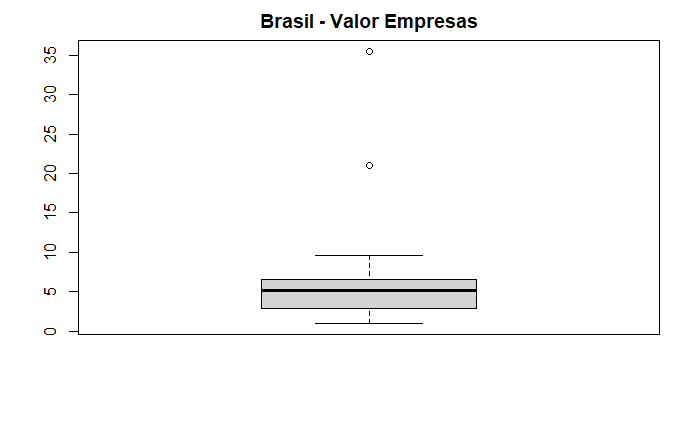

```r
boxplot(df$valor[which(df$pais == 'Brazil')],main = "Brasil - Valor Empresas")
```

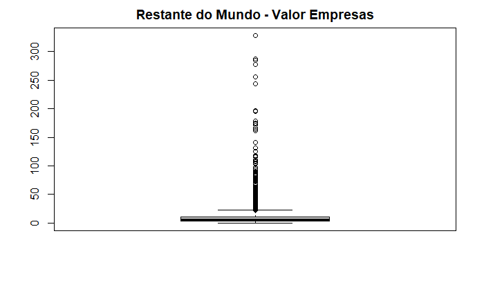

```r
boxplot(df$valor[which(df$pais != 'Brazil')],main = "Restante do Mundo - Valor Empresas")
```

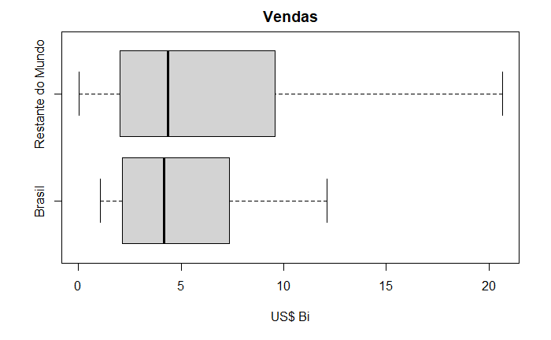

```r
boxplot(df$vendas[which(df$pais =="Brazil")],df$vendas[which(df$pais !="Brazil")],main= "Vendas",names = c("Brasil","Restante do Mundo"),xlab="US$ Bi",outline =FALSE,horizontal=TRUE)
```